# Introductory exercises

Eawag Summer School in Environmental Systems Analysis

Note, for the first three exercises you need only pencil and paper.

# 1. Joint, marginal and conditional distributions I ★

The joint discrete probability table of $P_{A,B}(a,b)$ is given below:

|  | B.1 | B.2 | B.3 |
| --- | --- | --- | --- |
| A.1 | 0.2 | 0.1 | 0.3 |
| A.2 | 0.1 | 0.1 | 0.2 |

Derive the following probabilities:

- $P_{A,B}(1,2)$
- $P_{B}(2)$
- $P_{A|B}(1|2)$
- Are $A$ and $B$ independent?

### Solution

- The joint probability $P_{A,B}(1,2) = 0.1$ can be read directly from the table.
- The marginal $P_{B}(2)$ is computed by summing over all joint probabilities with $B=2$, i.e. $P_{A,B}(1,2) + P_{A,B}(2,2) = 0.2$.
- Using the results from above we can compute the conditional probability $P_{A|B}(1|2)=\frac{P_{A,B}(1,2)}{P_{B}(2)}=0.5$.
- $A$ and $B$ are not independent. To see this calculate first the marginal probabilities. In this example the joint probability is not equal to the product of the marginal probabilities, $P_{A,B}(a,b) \neq P_{A}(a) \,P_{B}(b)$, hence $A$ and $B$ cannot be independent.

# 2. Joint, marginal and conditional distributions II ★

Assume the probability densities $p(E \mid B)$, $p(B)$, $p(A, D \mid E)$, and $p(C \mid B, E)$ are known.

- Draw the corresponding directed acyclic graph of the conditional probabilities to visualize the dependence structure.
- Derive $p(B, C, E)$
- Derive the joint distribution of $A$, $B$, $C$, $D$, and $E$.
- Derive $p(A, B \mid C, D, E)$
- Derive $p(A \mid D)$
- Derive $p(A \mid B, E)$

### Solution

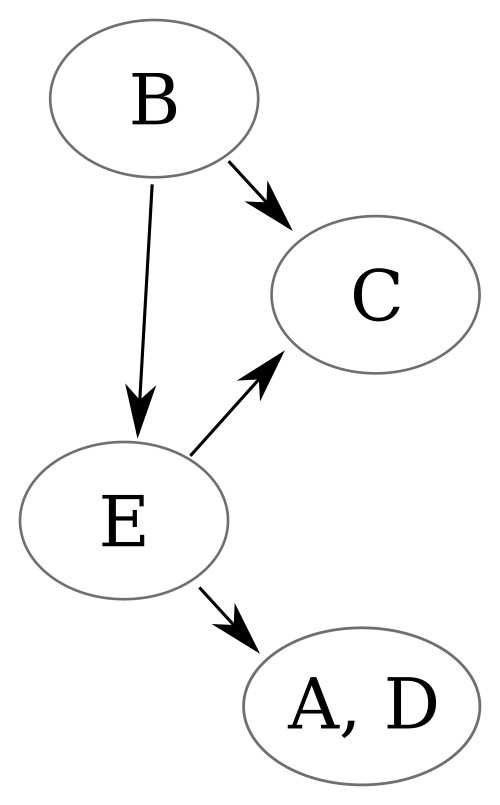

- $p(B, C, E) = p(C \mid B, E) \, p(E \mid B) \, p(B)$
- The joint distribution is
  $$p(A, B, C, D, E) = p(C \mid B, E) \, p(E \mid B) \, p(B) \,
  p(A, D \mid E)$$
- $$p(A, B \mid C, D, E) = \frac{p(A, B, C, D, E)}{p(C, D, E)}
  = \frac{p(A, B, C,
  D, E)}{\int p(A, B, C,
  D, E)\, dA\,dB}$$
- $$p(A \mid D) = \frac{p(A, D)}{p(D)} = \frac{\int p(A, B, C,
  D, E)\, dB\,dC\,dE}{\int p(A, B, C,
  D, E)\, dA\,dB\,dC\,dE}
  = \frac{\int p(A, D \mid E)\,p(E \mid B)\,p(B) dB\,dE}{\int p(A,
  D \mid E)\,p(E \mid B)\,p(B) dA\,dB\,dE}$$
- $$p(A \mid B, E) = \frac{\int p(A, D\mid E)\,p(E \mid B) \,p(B)
  \, dD}{p(E \mid B) \,p(B)}
  = \int p(A, D\mid E) \, dD = p(A \mid E)$$

# 3. Compound distribution ♛

Assume that:
$$\mu \sim f_{\mu}(m) =
\begin{cases}
0.1\exp(-0.1m) & m \geq 0 \\
0 & \text{else}
\end{cases}$$
and
$$X \sim f_{X|\mu=m}(x \mid m) = \frac{1}{\sqrt{2\pi}} \exp\left(-
\frac{(x-m)^2}{2}\right)$$

This means $X$ is normally distributed with mean $\mu$, and $\mu$ itself is exponentially distributed.

Derive and interpret:

- $f_{X, \mu}(x, m)$
- $f_{X}(x)$, a so called compound distribution.
- $P(\mu>5)$
- $f_{X,\mu|\mu>5}(x, m)$
- $f_{X|\mu>5}(x)$

It is not the aim to find closed forms for the integrals.

### Solution

- joint distribution:
  $$f_{X, \mu}(x, m) = f_{X|\mu}(x| m) \, f_{\mu}(m) = \frac{1}{\sqrt{2\pi}}
  e^{-\frac{(x-m)^2}{2}} 0.1e^{-0.1m}$$
- compound distribution
  $$f_{X}(x) = \int_0^\infty f_{X, \mu}(x, m) \,dm$$
- probability that $\mu$ is larger than 5:
  $$P(\mu>5) = \int_5^\infty f_{\mu}(m) \, dm = \exp (-0.1 \cdot 5)$$
- The joint distribution under the constraint that $\mu>5$:
  $$f_{X,\mu|\mu>5}(x, m)=
  \begin{cases}
  f_{X, \mu}(x, m) / P(\mu>5)& \text{if}\ m>5\\
  0 & \text{otherwise}
  \end{cases}$$
- marginal of $X$ under constrain that $\mu>5$:
  $$f_{X|\mu>5}(x) = \int_5^\infty f_{X,\mu|\mu>5}(x, m) \, dm
  \neq f_{X}(x)$$

# 4. Sampling vs. evaluating random variables ★

Take two random variables $X$ and $Y$ with the following distributions:
$$X \sim \text{Uniform}(0, 1)\\
Y \sim \text{Normal}(2, 10)$$

1. Evaluate the probability density $f_X(0.8)$ and $f_Y(0.8)$.
2. Generate 10000 samples from both random variables. Visualize the distributions as histograms.

Another random variable is defined as a function of $X$ as follows:
$$Z = \sin(2\pi X) \sqrt{X}$$
While it is difficult to derive the probability density $f_Z(z)$ analytically, sampling from it is easy.

3. Visualize the density $f_Z(z)$. First generate 10000 samples from $X$ and then transforming the samples. Visualize as histogram.

### Hints

#### R

Most important univariate probability distributions are already implemented in R. Type `?Distributions` to get an overview. For every distribution `__` four functions are defined with the following naming scheme:

```r
d__(x, ...)   # evaluate pdf at x
p__(x, ...)   # evaluate cdf at x
q__(p, ...)   # evaluate the p-th quantile
r__(n, ...)   # sample n random numbers
```

For example, for the normal distribution the functions are called `dnorm()`, `pnorm()`, `qnorm()`, and `rnorm()`.

Histograms are generated with the function `hist`. You can adjust the number of bins with the argument `breaks`, e.g. `hist(rnorm(10000), breaks=100)`.

#### Julia

The package `Distributions.jl` provides access to many probability distributions, see the [documentation](https://juliastats.org/Distributions.jl/stable/).

Here are some useful functions you can apply to all distributions (not only `Normal`):

```julia
π = Normal(0, 10) # define distribution

pdf(π, x)       # evaluate pdf at x
logpdf(π, x)    # evaluate log pdf at x
cdf(π, x)       # evaluate cdf at x
quantile(π, p)  # evaluate the p-th quantile
rand(π, n)      # sample n random numbers
```

Histograms are generated with the function `histogram` from the package `Plots.jl`. You can adjust the number of bins with the argument `nbins`, e.g `histogram(rand(Uniform(0,5), 10000), nbins = 100)`.

#### Python

This the Python solution:

```python
import numpy as np
x = np.random.normal(10)
np.mean(x)
```

```
## 9.092104321443431
```

Another code snippet

[figure not shown]

```python
import matplotlib.pyplot as plt
import numpy as np

xpoints = np.array([1, 2, 6, 8])
ypoints = np.array([3, 8, 1, 10])

plt.plot(xpoints, ypoints)
plt.show()
```

### Solution

#### R

1. evaluate pdf

```r
dunif(0.8, 0, 1)
```

```
## [1] 1
```

```r
dnorm(0.8, 2, 10)
```

```
## [1] 0.03960802
```

2. sample from distributions and plot them

```r
xs <- runif(10000, 0, 1)
ys <- rnorm(10000, 2, 10)
```

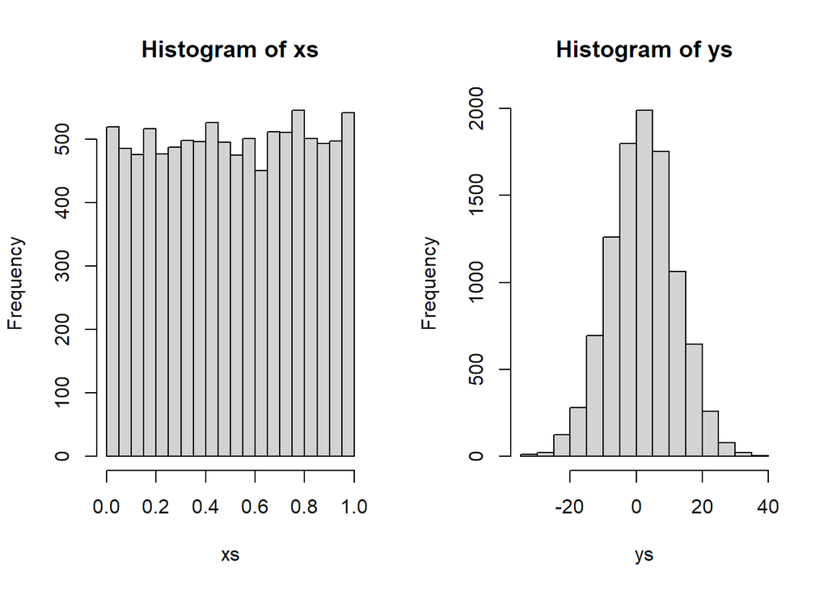

```r
par(mfrow=c(1,2))                       # optional, arranges both plots together
hist(xs)
hist(ys)
```

3. sample from $Z$

```r
xs <- runif(10000, 0, 1)                # sample from X
zs <- sin(2*pi*xs) * sqrt(xs)           # transfrom samples
```

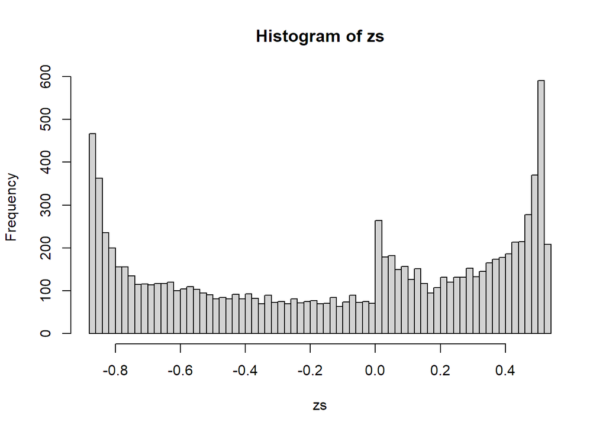

```r
hist(zs, breaks=75)
```

#### Julia

1. Evaluate pdf

```julia
using Distributions

X = Uniform(0,1)
Y = Normal(2, 10)
```

Use the function `pdf`(Probability Density Function)

```julia
pdf_X = pdf(X, 0.8)
```

```
## 1.0
```

```julia
pdf_Y = pdf(Y, 0.8)
```

```
## 0.03960802117936561
```

2. Sample from distributions and plot them

```julia
X_s = rand(X, 10000)
Y_s = rand(Y, 10000)
```

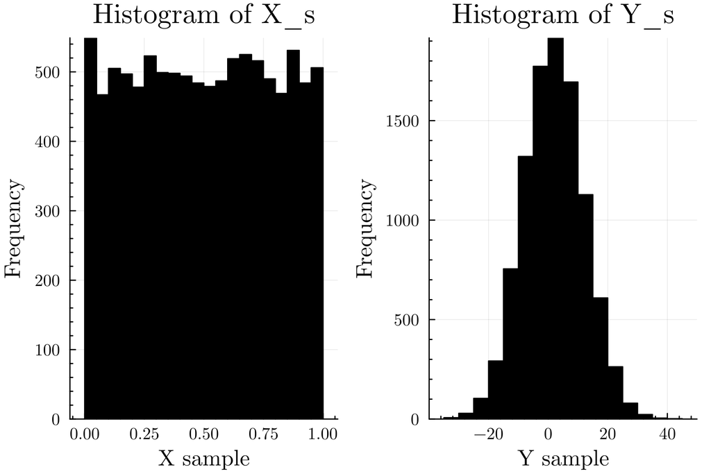

```julia
using Plots
p = [
  histogram(X_s, nbins = 20,
    labels=false,
    xlabel="X sample",
    ylabel="Frequency",
    title="Histogram of X_s"),
  histogram(Y_s, nbins = 20,
    labels=false,
    xlabel="Y sample",
    ylabel="Frequency",
    title="Histogram of Y_s")
];
plot(p...)
```

3. Sample from $Z$

```julia
Z_s = sin.(2*π*X_s).*sqrt.(X_s) #the dot symbol means that the operation is done component by component
```

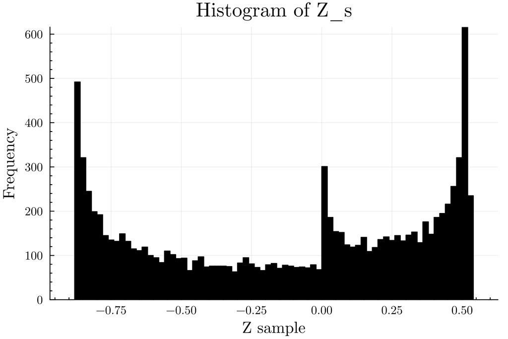

```julia
histogram(Z_s, nbins = 75,
    labels=false,
    xlabel="Z sample",
    ylabel="Frequency",
    title="Histogram of Z_s")
```

# 5. Generating data ★

Generate 1000 samples of two different 2-dimensional normal distributions. The mean of both distribution is $\boldsymbol{\mu}=(3,8)$.

- For the first distribution, $\boldsymbol{Y}_\mathrm{obs,indep}$, both dimensions are *independent* and have a standard deviations of $\boldsymbol{\sigma}_\mathrm{obs,indep}=(2,5)$.
- The second distribution, $\boldsymbol{Y}_\mathrm{obs,dep}$, the two dimensions are correlated. This is defined with the covariance matrix
  $$\boldsymbol{\Sigma}_\mathrm{obs,dep}=
  \begin{pmatrix}
  4 & 8\\
  8 & 25
  \end{pmatrix}$$
  .

The aim is obtain two matrices(with two columns and 1000 rows) containing the random samples.

### Hints

#### R

You can use `rnorm()` to sample form a one-dimensional normal distribution. With `cbind()` you can combine vectors to a matrix. For the depended normal distribution use `rmvnorm()` from the package `mvtnorm`.

#### Julia

Given a mean vector $\mu$ and a correlation matrix $\Sigma$, you can construct a multivariate normal distribution with `MvNormal(μ, Σ)` from the package `Distribution.jl`. How does the covariance matrix for independent variables look like?

### Solution

#### R

```r
library(mvtnorm)
y.obs.indep <- cbind(rnorm(1000, mean=3, sd=2),
                     rnorm(1000, mean=8, sd=5))
Sigma.dep <- matrix(c(4,8,8,25), nrow=2, ncol=2)
y.obs.dep <- rmvnorm(1000, mean=c(3,8), sigma=Sigma.dep)
```

#### Julia

```julia
using Distributions

μs = [3, 8]
Σ_indep = [2^2 0; 0 5^2]
Σ_dep = [4 8; 8 25]

Y_1 = MvNormal(μs, Σ_indep)
y_1_sample = rand(Y_1, 1000)

Y_2 = MvNormal(μs, Σ_dep)
y_2_sample = rand(Y_2, 1000)
```

# 6. Analyzing and visualizing data ★

Perform some preliminary analysis of the data generated in Task 5:

1. What are the interquartile and the 90%-interquantile ranges of your samples?
2. Plot and compare the histograms and the densities of all the marginals
3. Compare the scatterplots of $\boldsymbol{Y}_\mathrm{obs,indep}$ and $\boldsymbol{Y}_\mathrm{obs,dep}$
4. Compute the covariance and the correlation matrix of $\boldsymbol{Y}_\mathrm{obs,indep}$ and $\boldsymbol{Y}_\mathrm{obs,dep}$

Which of the above steps reveal a potential correlation structure in your data?

### Hints

#### R

Try to arrange multiple plots in the same window by setting `par(mfrow=c(<nrow>,<ncol>))`. Use `quantile()` to calculate the interquantile range; use `hist()` and `plot(density())` to visualize the data; use `cov()`,`cor()` for the covariance and the correlation, respectively.

#### Julia

You can use the function `quantile` from the [`Statistics.jl`](https://docs.julialang.org/en/v1/stdlib/Statistics/) module. It provides also functions to compute the covariance and correlation matrix.

The package [`Plots.jl`](https://docs.juliaplots.org/stable/) provides basic plotting function such as `scatter` and `histogram`. For density plots and other more specialized plots look at [`StatsPlots.jl`](https://docs.juliaplots.org/latest/generated/statsplots/).

### Solution

#### R

1. Quantiles

```r
quartiles.indep <- cbind(quantile(y.obs.indep[,1], probs = c(0.25,0.75)),
                         quantile(y.obs.indep[,2], probs = c(0.25,0.75)))
                                        # Or with `apply`:
quartiles.indep <- apply(y.obs.indep, MARGIN=2, FUN=quantile, probs=c(0.25,0.75))

                                        # then we use apply
quartiles.dep <- apply(y.obs.dep, MARGIN=2, FUN=quantile, probs=c(0.25,0.75))
quant5_95.indep <- apply(y.obs.indep, MARGIN=2, FUN=quantile, probs=c(0.05,0.95))
quant5_95.dep <- apply(y.obs.dep, MARGIN=2, FUN=quantile, probs=c(0.05,0.95))
cat("Interquartile range\nIndep: ", diff(quartiles.indep),
    "\nDep: ", diff(quartiles.dep), "\n")
```

```
## Interquartile range
## Indep:  2.612028 6.621222
## Dep:  2.636368 6.601866
```

2. Histograms and densities

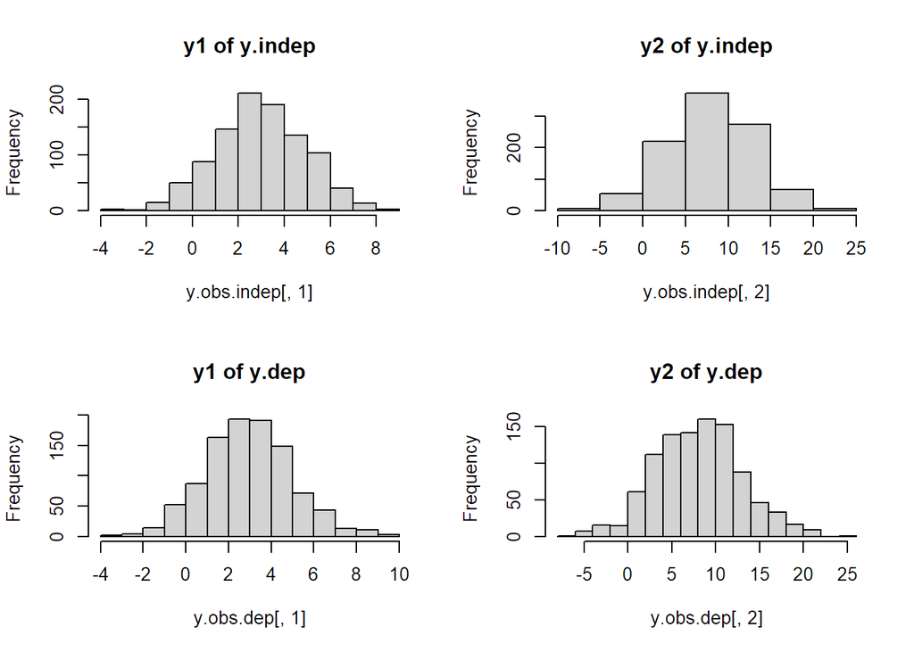

```r
par(mfrow=c(2,2))
hist(y.obs.indep[,1], main="y1 of y.indep")
hist(y.obs.indep[,2], main="y2 of y.indep")
hist(y.obs.dep[,1],   main="y1 of y.dep")
hist(y.obs.dep[,2],   main="y2 of y.dep")
```

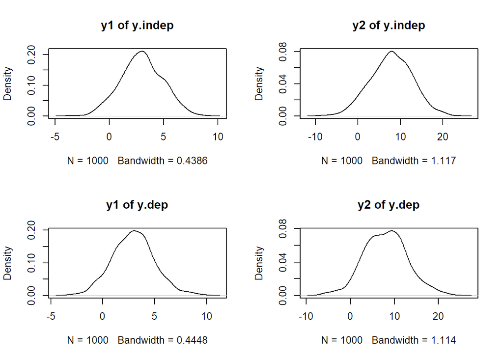

```r
par(mfrow=c(2,2))
plot(density(y.obs.indep[,1]), main="y1 of y.indep")
plot(density(y.obs.indep[,2]), main="y2 of y.indep")
plot(density(y.obs.dep[,1]),   main="y1 of y.dep")
plot(density(y.obs.dep[,2]),   main="y2 of y.dep")
```

3. Scatterplots

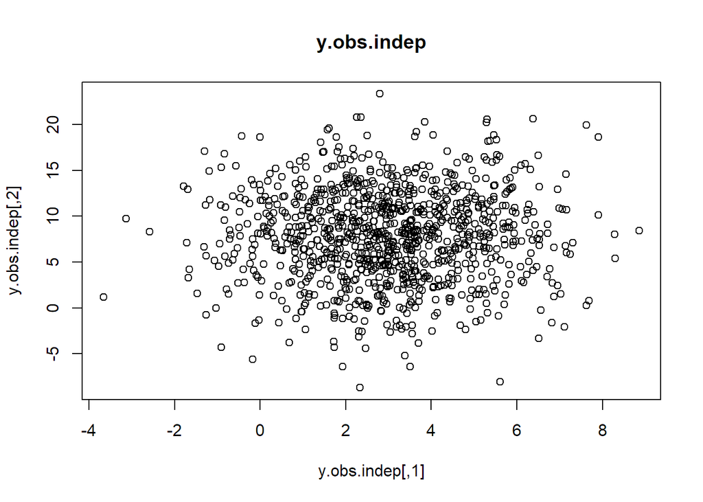

```r
plot(y.obs.indep, main="y.obs.indep")
```

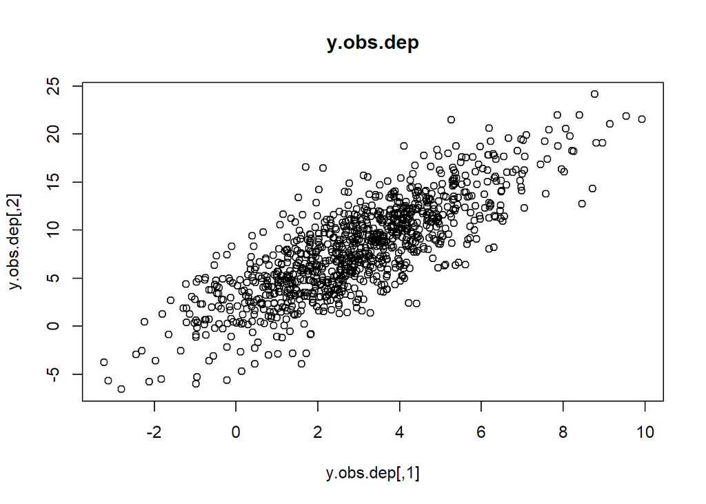

```r
plot(y.obs.dep, main="y.obs.dep")
```

4. Covariance and correlation

```r
covariance.indep <- cov(y.obs.indep)
covariance.dep <- cov(y.obs.dep)
correlation.indep <- cor(y.obs.indep)
correlation.dep <- cor(y.obs.dep)
```

#### Julia

1. Quantiles

```julia
using Statistics
using StatsBase

interquartiles_indep = [iqr(y_1_sample[1, :]),
                        iqr(y_1_sample[2, :])]
```

```
## 2-element Vector{Float64}:
##  2.9241113482433203
##  6.715925845568873
```

```julia
interquartiles_dep = [iqr(y_2_sample[1, :]),
                      iqr(y_2_sample[2, :])]
```

```
## 2-element Vector{Float64}:
##  2.83388998910908
##  7.036664668080391
```

```julia
inter_5_95_quantile_indep = [diff(quantile(y_1_sample[1, :], [0.05, 0.95])),
                             diff(quantile(y_1_sample[2, :], [0.05, 0.95]))]
```

```
## 2-element Vector{Vector{Float64}}:
##  [6.78323180452401]
##  [16.673847389100892]
```

```julia
inter_5_95_quantile_dep = [diff(quantile(y_2_sample[1, :], [0.05, 0.95])),
                           diff(quantile(y_2_sample[2, :], [0.05, 0.95]))]
```

```
## 2-element Vector{Vector{Float64}}:
##  [6.531518933885161]
##  [16.75260008428177]
```

2. Histograms and densities

```julia
hist = [
    histogram(y_1_sample[1, :], nbins = 15,
              xlabel="y_1_sample[1,:]"),
    histogram(y_1_sample[2, :], nbins = 15,
              xlabel="y_1_sample[2,:]"),
    histogram(y_2_sample[1, :], nbins = 15,
              xlabel="y_2_sample[1,:]"),
    histogram(y_2_sample[2, :], nbins = 15,
              xlabel="y_2_sample[2,:]")
]
```

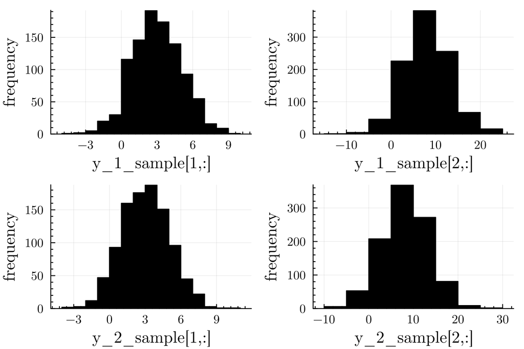

```julia
plot(hist..., legend = false, ylabel = "frequency")
```

```julia
using StatsPlots
dens = [
    density(y_1_sample[1,:],
            xlabel="y_1_sample[1,:]"),
    density(y_1_sample[2,:],
            xlabel="y_1_sample[2,:]"),
    density(y_2_sample[1,:],
            xlabel="y_2_sample[1,:]"),
    density(y_2_sample[2,:],
            xlabel="y_2_sample[2,:]")
]
```

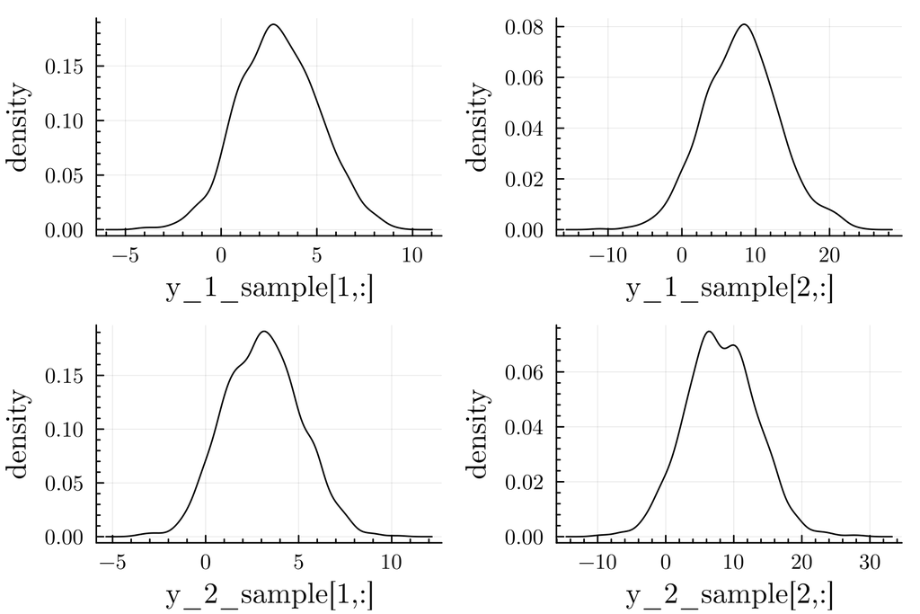

```julia
plot(dens..., legend = false, ylabel = "density")
```

Alternatively, we could also have written a loop for the four plots.

3. Scatterplots

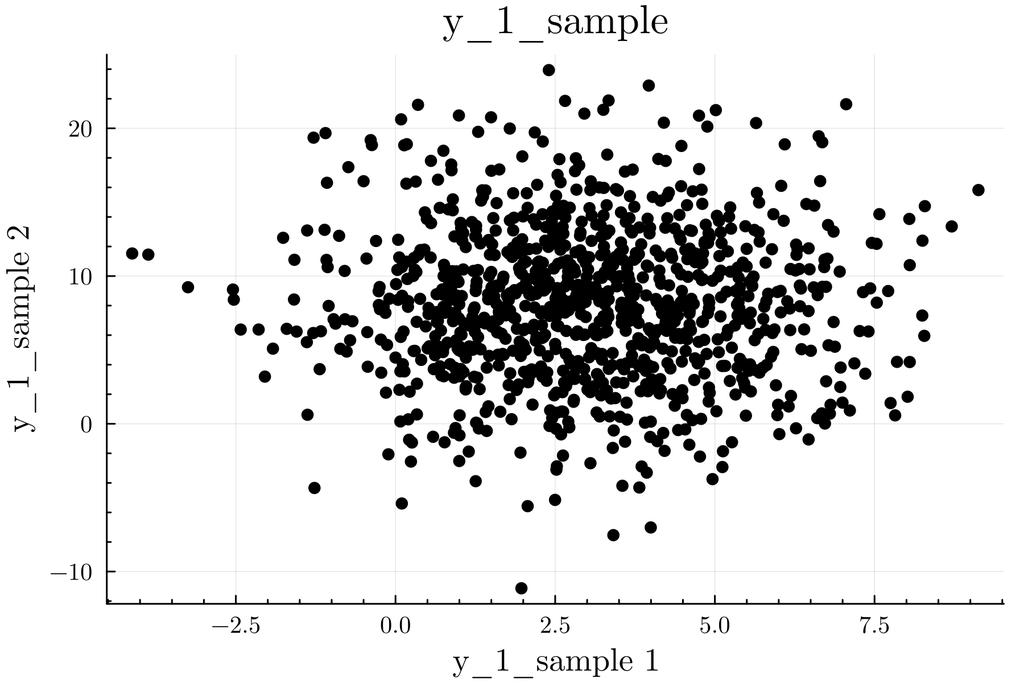

```julia
scatter(y_1_sample[1, :], y_1_sample[2, :],
        labels=false,
        xlabel="y_1_sample 1",
        ylabel="y_1_sample 2",
        title="y_1_sample")
```

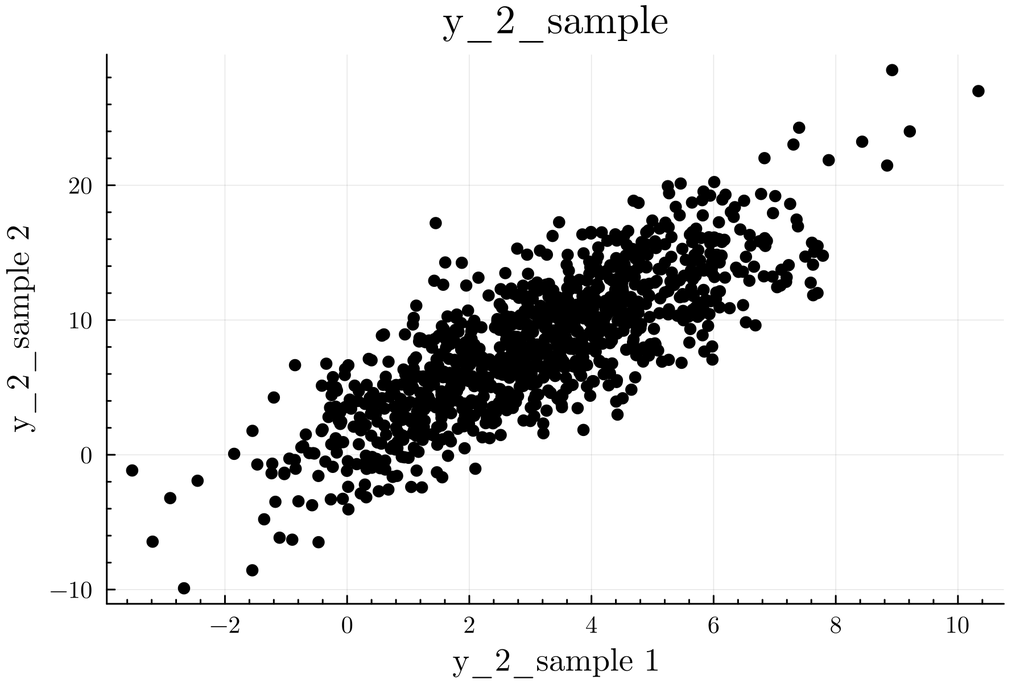

```julia
scatter(y_2_sample[1, :], y_2_sample[2, :],
        labels=false,
        xlabel="y_2_sample 1",
        ylabel="y_2_sample 2",
        title="y_2_sample")
```

4. Covariance and correlation

```julia
using Statistics
Statistics.cov(y_1_sample, dims=2)
```

```
## 2×2 Matrix{Float64}:
##   4.34733   -0.175091
##  -0.175091  26.1964
```

```julia
Statistics.cov(y_2_sample, dims=2)
```

```
## 2×2 Matrix{Float64}:
##  4.09646   8.51782
##  8.51782  27.2086
```

```julia
Statistics.cor(y_1_sample, dims=2)
```

```
## 2×2 Matrix{Float64}:
##   1.0        -0.0164071
##  -0.0164071   1.0
```

```julia
Statistics.cor(y_2_sample, dims=2)
```

```
## 2×2 Matrix{Float64}:
##  1.0       0.806809
##  0.806809  1.0
```

# 7. Working with dataframes ★

Real data often contain columns of different data types (e.g. numbers and strings). Dataframes are designed to work with this kind of data conveniently.

1. Import the file `./data/model_growth.csv` as dataframe. Perform some analyses similar to the ones in Task 6.
2. Add a new column (say `C_new`) to the growth data frame that contains some random values .

### Hints

#### R

Read the data using `read.table("</path/to/somefile.txt>", header=TRUE)` to indicate that the first row are the column names (use file `../data/model_growth.csv`). To select the column `C_M` from a dataframe, say `data`, you can use `data$C_M` or `data[,"C_M"]`.

To add columns, you can use `cbind` to column-bind the new data to the available matrix and convert everything to a `data.frame`. Then, you can rename the columns by assigning the desired names with function `colnames()` applied to the newly created `data.frame`.

#### Julia

Use the package `DataFrames.jl` to read and manipulate data. To import csv (comma separated values) files, we also use `CSV.jl`. You can use `pwd()` the find your currently working directory.

```julia
using DataFrames
import CSV

path = joinpath("data", "myfile.csv")
data = DataFrame(CSV.File(path; delim=";"))

# select columns "x"
data.x
```

### Solution

#### R

```r
## Loading data
## ----------------------------------------------
growth.dat <- read.table("../../data/model_growth.csv", header=TRUE)
C_M <- growth.dat$C_M
C_S <- growth.dat$C_S
```

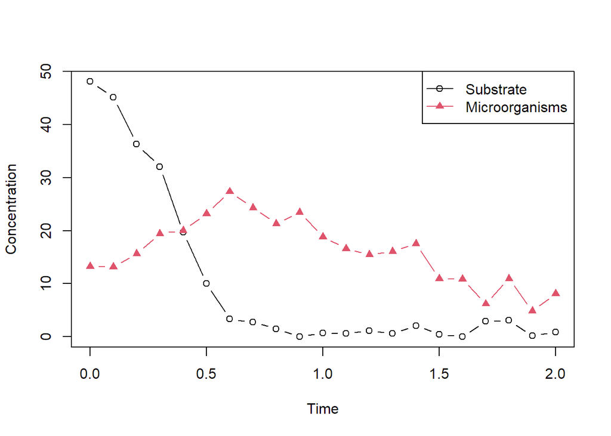

```r
## Plotting data
## ----------------------------------------------
plot(growth.dat$t, growth.dat$C_S, type="b", xlab="Time", ylab="Concentration")
lines(growth.dat$t, growth.dat$C_M, type="b", pch=17, col=2)
legend("topright", legend=c("Substrate", "Microorganisms"), col=c(1,2), pch=c(1,17), lty=1)
```

```r
## Combining Data
## ----------------------------------------------
## Data for new row
y <- rnorm(nrow(growth.dat))

## Add the row to the dataframe
growth.dat.2 <- cbind(growth.dat, C_new = y)
head(growth.dat.2)
```

```
##     t      C_M      C_S      C_new
## 1 0.0 13.27717 48.10293  0.3166206
## 2 0.1 13.19659 45.11676  1.0156368
## 3 0.2 15.62860 36.28523 -2.1743093
## 4 0.3 19.44555 32.06841 -0.5485063
## 5 0.4 20.05754 19.68459  1.0657985
## 6 0.5 23.17631 10.07305 -1.2958884
```

#### Julia

```julia
using CSV
using DataFrames
pwd()
```

Given your working directory, go to the desired file with a relative path. Remember that `..` allows to come one step back.

```julia
growth_dat = CSV.read(joinpath("..", "..", "data", "model_growth.csv"),
                      DataFrame)
# show(growth_dat, allrows=true) if you want to see all you data
```

Extraction of a column can be done with the following syntax.

```julia
C_M = growth_dat[:, "C_M"]
C_S = growth_dat[:, "C_S"]
time = growth_dat[:, "t"]
## or alternatively
time = growth_dat.t
```

Plotting

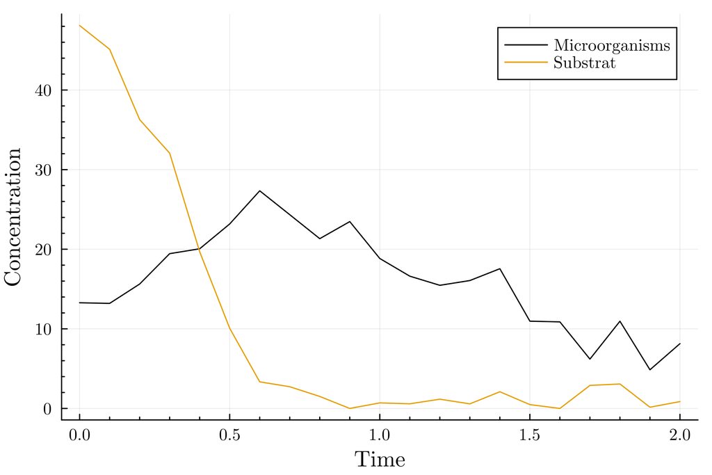

```julia
plot(time, C_M,
    labels="Microorganisms",
    xlabel="Time",
    ylabel="Concentration");
plot!(time, C_S,
    labels="Substrat")
```

b.

```julia
# generate some data
C_new = rand(nrow(growth_dat))

# add new column
growth_dat.Cnew = C_new
```

# 8. Error propagation and functions

If $f()$ is non-linear, generally,
$$f(E[X]) \neq E[f(X)]$$
where $E$ is the expected value and $X$ is a random variable. Implement the non-linear function $f(x) = \sin\sqrt{x}$ and assume that $X$ is log-normally distribute. Use samples to estimate $f(E[X])$, $E[f(X)]$, $\mathrm{Var}[X]$, $\mathrm{Var}[f(X)]$ and compare them.

### Hints

#### R

Use `rlnorm` to sample from a log-normal distribution, which accepts the mean and the standard deviation on the log-scale, not on the original scale. Additionally, keep in mind that in R a general function can be defined as:

```r
function.name <- function(arg1,arg2){
  result <- arg1 + arg2 # or any other operation
  return(result)
}
```

Most basic functions are already available, and those include both `sin` and `sqrt`. Try `?sin` in the R console to get access to the manual of the harmonic functions. These can be used anywhere in the code, including inside a custom function.

#### Julia

Use `LogNormal()` from the package `Distributions.jl`for a log-normal distribution. You can create you own Julia functions following the syntax

```julia
function choose_your_name(arg_1, arg_2)
    res = arg_1 + arg_2
    return res
end
```

Very short functions can be defined as

```julia
foo(a, b) = a + b
```

### Solution

#### R

```r
fun <- function(x){
  return(sin(sqrt(x)))
}

X <- rlnorm(1000, meanlog=0, sdlog=1)
```

[output not shown]

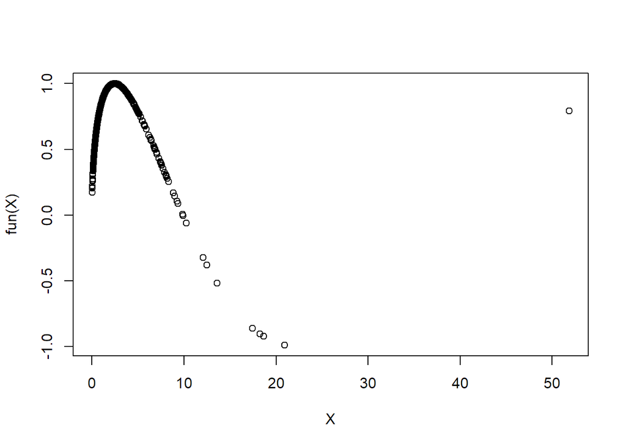

```r
plot(X,fun(X))
```

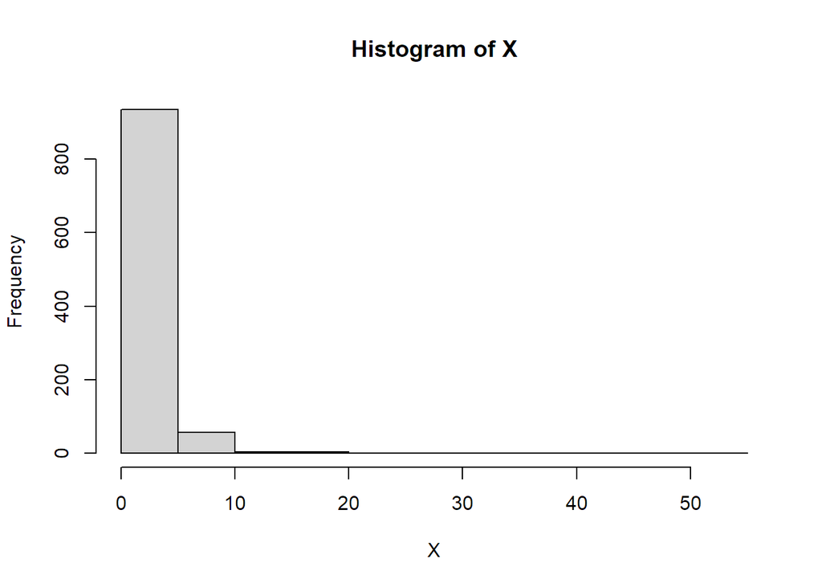

```r
hist(X)
```

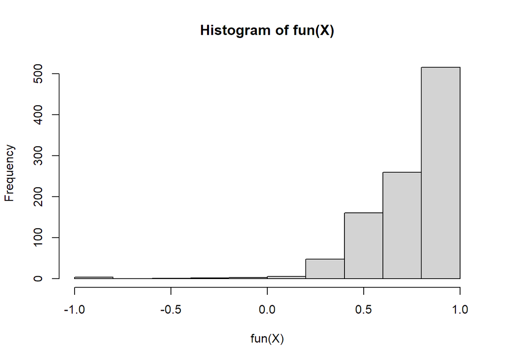

```r
hist(fun(X))
```

#### Julia

```julia
f(x) = sin(sqrt(x))
```

```julia
x = rand(LogNormal(), 1000)
```

```julia
using Statistics

# mean of X
mean(x)
```

```
## 1.649934890883919
```

```julia
# mean of f(X)
mean(f.(x))
```

```
## 0.7521225980610422
```

```julia
# f(mean of X)
f(mean(x))
```

```
## 0.9592957853722808
```

```julia
# variance of x
var(x)
```

```
## 4.2229843306515225
```

```julia
# variance of f(X)
var(f.(x))
```

```
## 0.059959791115422274
```

Plotting

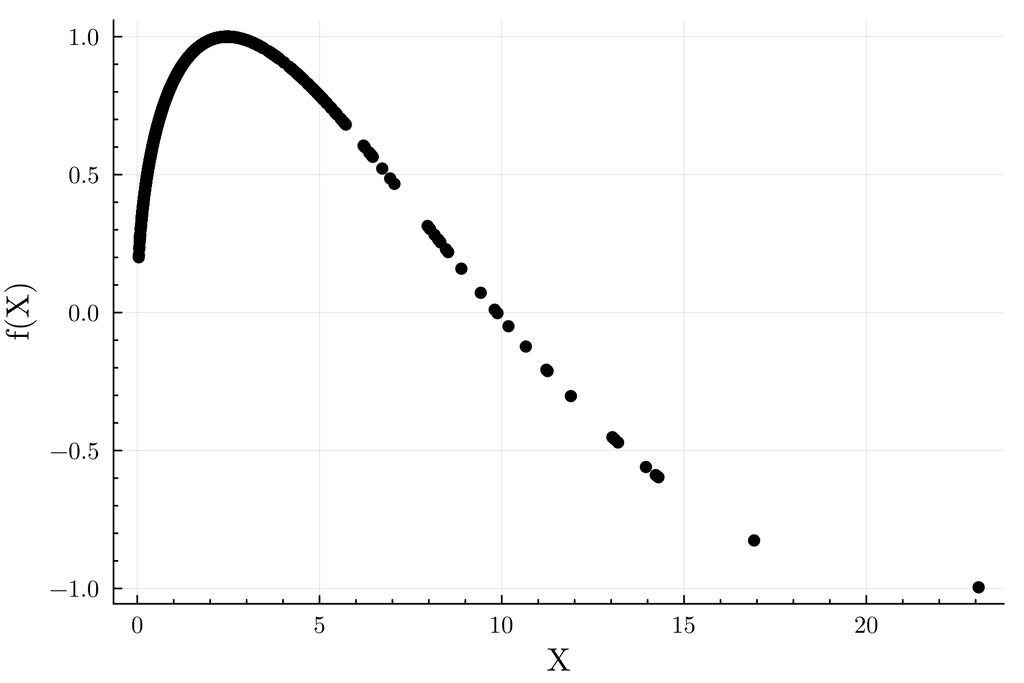

```julia
using Plots

scatter(x, f.(x),
        labels = false,
        xlabel = "X",
        ylabel = "f(X)")
```

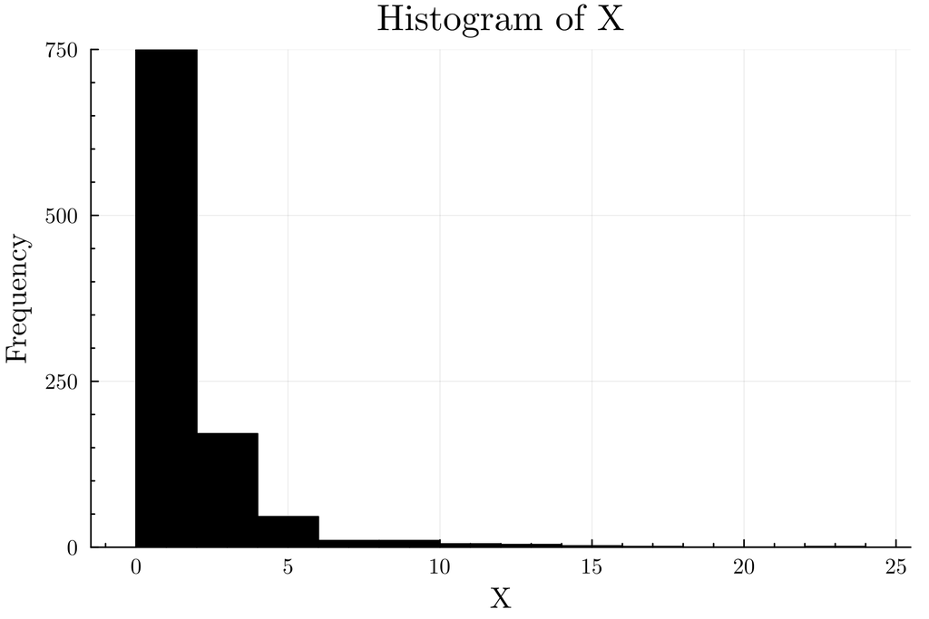

```julia
histogram(x, nbins=20,
          labels = false,
          xlabel = "X",
          ylabel = "Frequency",
          title = "Histogram of X")
```

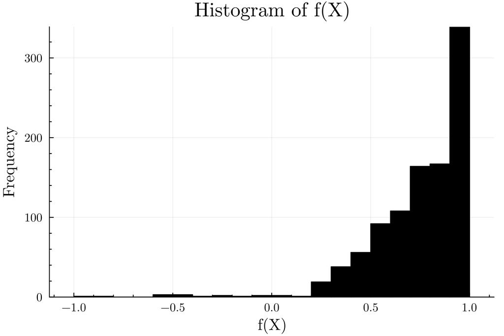

```julia
histogram(f.(x), nbins=20,
          labels = false,
          xlabel = "f(X)",
          ylabel = "Frequency",
          title = "Histogram of f(X)")
```